# Zero inflated poisson model for Barents fishes data

Donnet, Gloaguen, Robin

2025-01-07

```r
library(extraDistr)
library(ggplot2)
library(knitr)
```

## 1. The Barents Fish dataset

Species distribution models (SDM) aim at understanding how environmental conditions affect the abundance of a given species in a given site. The data are typically collected in the following way: $n$ sites are visited and in each site $i$ ($1 \leq i \leq n$) a $d$-dimensional vector $x_i$ of environmental descriptors is recorded, as well as the number $y_i$ of individuals of the species observed in the site.

Map of the Barents sea, where data were collected

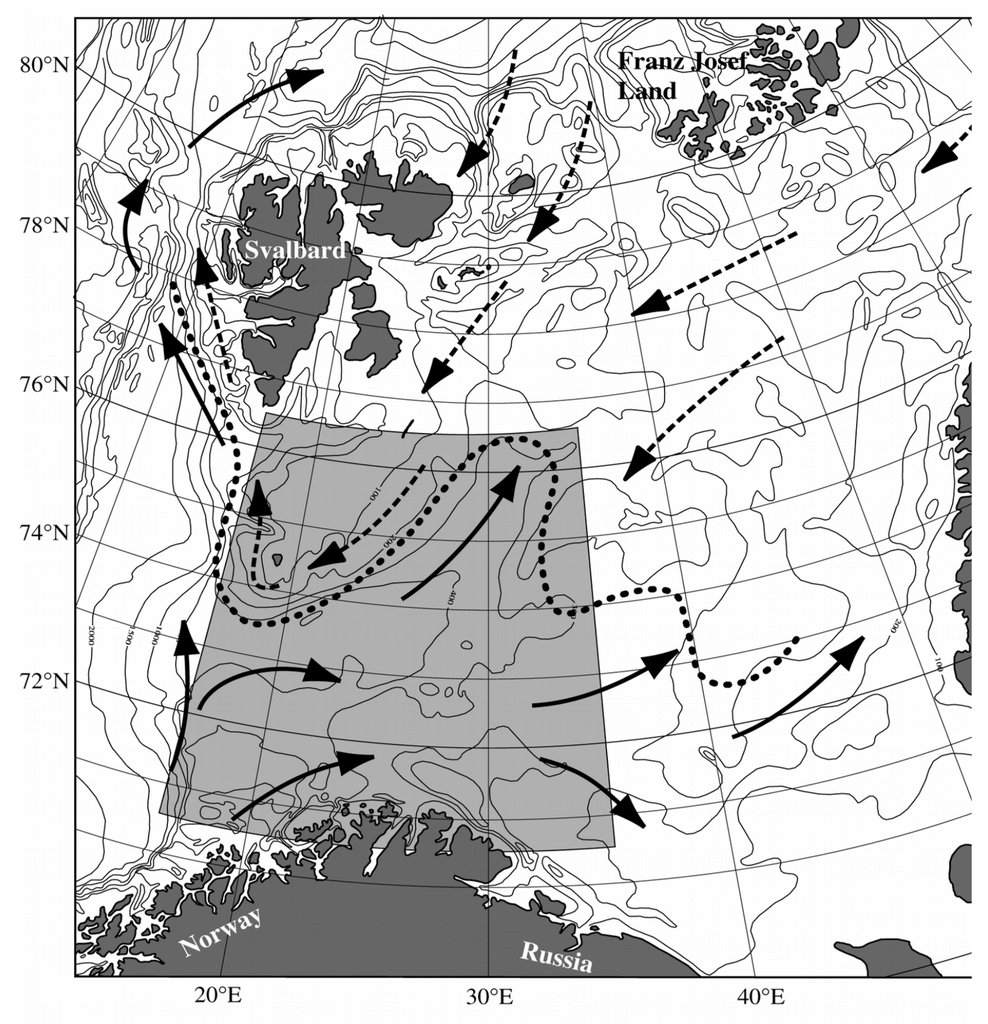

We first give the first few lines of the dataset and the histogram of the observed abundances, which display a large variance and a high number of observations equal to $0$: the species is actually not observed (i.e. $y_i = 0$) in $n_0 = 61$ stations.

```r
dataCodBarents <- read.table('BarentsFish.csv', sep=';', header=TRUE)
Covariates <- as.matrix(dataCodBarents[, (2:5)])
Counts <- dataCodBarents[, 6:ncol(dataCodBarents)]
j <- 21 # We focus on Species Ga_mo
Abundance <- Counts[, j]; Presence <- (Abundance>0)
Cod<- as.data.frame(Covariates)
Cod$Abundance <-Abundance
Cod$Presence <- Presence
```

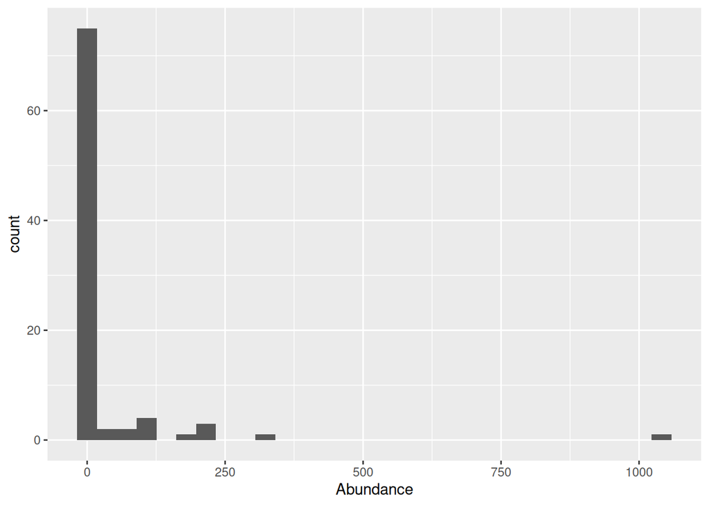

|  | Latitude | Longitude | Depth | Temperature | Abundance | Presence |
| --- | --- | --- | --- | --- | --- | --- |
| 1 | 71.10 | 22.43 | 349 | 3.95 | 309 | TRUE |
| 2 | 71.32 | 23.68 | 382 | 3.75 | 1041 | TRUE |
| 3 | 71.60 | 24.90 | 294 | 3.45 | 218 | TRUE |
| 4 | 71.27 | 25.88 | 304 | 3.65 | 77 | TRUE |
| 5 | 71.52 | 28.12 | 384 | 3.35 | 13 | TRUE |
| 10 | 71.30 | 32.15 | 256 | 3.35 | 0 | FALSE |
| 11 | 71.22 | 33.15 | 254 | 2.55 | 0 | FALSE |
| 12 | 71.58 | 32.37 | 297 | 2.65 | 0 | FALSE |

We renormalize the covariates.

```r
p <- 1+ncol(Covariates)
Covariates <- as.matrix(scale(Covariates))
Barents <- as.data.frame(cbind(Covariates, Abundance))
names(Barents)[5] <- 'Abundance'
Covariates <- cbind(rep(1, n), Covariates)
colnames(Covariates)[1] <- 'Intercept'
```

## 2. Classical Poisson or logistic regression approaches.

The model can be adapted to account for heterogeneous sampling efforts (e.g. different observation times) by adding an known site-specific offset term $o_i$ to the regression model. The unknown parameter $\theta$ is only the vector of regression coefficients $\beta$, its estimation (by maximizing the likelihood) and interpretation are straightforward.

```r
# Poisson regression model for the Abundance
regP <- glm(Abundance ~ Latitude + Longitude + Depth + Temperature, data=Barents, family='poisson')
summary(regP)
```

```
##
## Call:
## glm(formula = Abundance ~ Latitude + Longitude + Depth + Temperature,
##     family = "poisson", data = Barents)
##
## Coefficients:
##              Estimate Std. Error z value Pr(>|z|)
## (Intercept)  0.009781   0.085862   0.114    0.909
## Latitude    -0.721225   0.117634  -6.131 8.73e-10 ***
## Longitude   -0.042936   0.032051  -1.340    0.180
## Depth        0.916611   0.025273  36.268  < 2e-16 ***
## Temperature  2.478534   0.114704  21.608  < 2e-16 ***
## ---
## Signif. codes:  0 '***' 0.001 '**' 0.01 '*' 0.05 '.' 0.1 ' ' 1
##
## (Dispersion parameter for poisson family taken to be 1)
##
##     Null deviance: 12865.9  on 88  degrees of freedom
## Residual deviance:  2148.5  on 84  degrees of freedom
## AIC: 2295.7
##
## Number of Fisher Scoring iterations: 7
```

```r
regP$beta <- regP$coefficients
```

Alternatively, one may aim at understanding the drivers of the simple presence of the species in each site. One way is to consider the binary variable which equal to $1$ is the count is strictly positive, $0$ otherwise and to use a logistic regression model:

```r
Barents$Presence = 1*(Barents$Abundance>0)
regL <- glm(Presence ~  Latitude + Longitude + Depth + Temperature, data=Barents, family='binomial')
regL$alpha <- regL$coefficients
regL$linPred <- as.vector(Covariates%*%regL$alpha)
logLik(regL)
```

```
## 'log Lik.' -29.29516 (df=5)
```

```r
summary(regL)
```

```
##
## Call:
## glm(formula = Presence ~ Latitude + Longitude + Depth + Temperature,
##     family = "binomial", data = Barents)
##
## Coefficients:
##             Estimate Std. Error z value Pr(>|z|)
## (Intercept)  -1.2753     0.3670  -3.475 0.000511 ***
## Latitude     -0.2506     0.6646  -0.377 0.706134
## Longitude     0.3009     0.4030   0.747 0.455265
## Depth        -0.3869     0.3837  -1.008 0.313313
## Temperature   1.9941     0.6823   2.923 0.003470 **
## ---
## Signif. codes:  0 '***' 0.001 '**' 0.01 '*' 0.05 '.' 0.1 ' ' 1
##
## (Dispersion parameter for binomial family taken to be 1)
##
##     Null deviance: 110.85  on 88  degrees of freedom
## Residual deviance:  58.59  on 84  degrees of freedom
## AIC: 68.59
##
## Number of Fisher Scoring iterations: 5
```

This model also suffers limitation, because the presence of the species is not directly observed. Indeed, whenever the species is not observed ($Y_i = 0$), it is not possible to decide whether it is actually absent from the site, or simply unobserved (the two cases are sometimes referred to as ‘true zero’ versus ‘false zero’).

## 3. ZIP model

We consider the ZIP model presented in the Class.

### 3.a Functions

The useful functions are in the file `FunctionsZIPreg.R`.

```r
source('FunctionsZIPreg.R')
```

Have a look at the codes

### 3.b Run the EM

```r
thetaInit <- InitZIP(X=Covariates, Y=Abundance)
em <- EMZIPreg(X=Covariates, Y=Abundance, thetaInit=thetaInit)
```

```
## iter 2
## -0.9208967 -0.139851 0.2837439 -0.5660354 1.784963 1.494935 -0.3852219 -0.256608 0.8664746 1.876195 1.485154 -892.3938
## iter 3
## -0.9704102 -0.2033428 0.3579273 -0.5653342 1.689021 1.528935 -0.3523572 -0.2594829 0.8664457 1.883845 0.09594166 -892.1953
## iter 4
## -0.9663127 -0.247716 0.3714958 -0.5647264 1.643797 1.543748 -0.372098 -0.2646722 0.864083 1.856969 0.04522449 -892.1628
## iter 5
## -0.960954 -0.2668028 0.3728521 -0.5689256 1.621961 1.544026 -0.372099 -0.264938 0.8640869 1.856701 0.02183546 -892.1604
## iter 6
## -0.9579928 -0.2758148 0.3733262 -0.5715473 1.609573 1.544026 -0.372099 -0.264938 0.8640869 1.856701 0.01238802 -892.1596
## iter 7
## -0.9551884 -0.2807287 0.3735456 -0.5734176 1.602532 1.544026 -0.372099 -0.264938 0.8640869 1.856701 0.007041541 -892.1594
## iter 8
## -0.9537642 -0.2835233 0.3738369 -0.5747695 1.598074 1.544026 -0.372099 -0.264938 0.8640869 1.856701 0.004458231 -892.1593
## iter 9
## -0.9523285 -0.2849615 0.3737477 -0.5757986 1.595363 1.544026 -0.372099 -0.264938 0.8640869 1.856701 0.002710613 -892.1592
## iter 10
## -0.9516835 -0.2857548 0.3737287 -0.5762628 1.593824 1.544026 -0.372099 -0.264938 0.8640869 1.856701 0.001538903 -892.1592
## iter 11
## -0.9512547 -0.2861404 0.3738916 -0.5766751 1.59319 1.544026 -0.372099 -0.264938 0.8640869 1.856701 0.0006343814 -892.1592
## iter 12
## -0.9510709 -0.28605 0.3738501 -0.5771132 1.592726 1.544026 -0.372099 -0.264938 0.8640869 1.856701 0.0004642512 -892.1592
## iter 13
## -0.9507453 -0.2864516 0.3742083 -0.5770331 1.592106 1.544026 -0.372099 -0.264938 0.8640869 1.856701 0.00061946 -892.1592
## iter 14
## -0.950547 -0.2867738 0.37427 -0.5773241 1.591798 1.544026 -0.372099 -0.264938 0.8640869 1.856701 0.0003222188 -892.1592
## iter 15
## -0.9504101 -0.2866875 0.3742244 -0.5773307 1.591723 1.544026 -0.372099 -0.264938 0.8640869 1.856701 0.0001368686 -892.1592
## iter 16
## -0.9504101 -0.2866875 0.3742244 -0.5773307 1.591723 1.544026 -0.372099 -0.264938 0.8640869 1.856701 0 -892.1592
```

We also consider alternative methods : a direct optimization and we use the R package `pscl` We will compare the performances of the methods by comparing the final Log Likelihoods.

```r
# Direct optimization
opt <- optim(unlist(thetaInit), f=LogLikZIP, Y=Abundance, X=Covariates, control=list(fnscale=-1))
opt$alpha <- opt$par[1:ncol(Covariates)]; opt$beta <- opt$par[-(1:ncol(Covariates))]
opt$theta <- list(alpha=opt$alpha, beta=opt$beta)
# Package
```

```r
library(pscl)
fit <- zeroinfl(Abundance ~ -1 + Covariates, dist="poisson")
fit$theta <- list(alpha=fit$coefficients$zero, beta=fit$coefficients$count)

LL <- c(LogLikZIP(unlist(thetaInit), X=Covariates, Y=Abundance),
  LogLikZIP(unlist(opt$theta), X=Covariates, Y=Abundance),
  LogLikZIP(unlist(fit$theta), X=Covariates, Y=Abundance),
  LogLikZIP(unlist(em$theta), X=Covariates, Y=Abundance))
names(LL) = c('Init','Optim','pscl',"EM")
print(LL)
```

```
##      Init     Optim      pscl        EM
## -988.3747 -894.6347 -975.5075 -892.1592
```

The EM leads to a higher likelihood value. We keep the required quantities.

```r
regZIP <- em
regZIP$linPredPresence <- Covariates%*%regZIP$theta$alpha
regZIP$linPredAbundance <- Covariates%*%regZIP$theta$beta
regZIP$tau <- regZIP$tau[, 2]
```

## 3. Results

### 3.a Parameter estimates

We now compare the estimates with the 3 models (ZIP, Logistic and Poisson)

```r
regCoef <- matrix(NA,3,p*2)
rownames(regCoef) <- c('Logistic', 'Poisson', 'ZIP')
colnames(regCoef) <- c(names(regP$coefficients), names(regL$coefficients))
regCoef[1,1:p] <- round(regL$alpha,3)
regCoef[2,p+(1:p)] <- round(regP$beta,3)
regCoef[3,] <- round(as.vector(c(regZIP$theta$alpha, regZIP$theta$beta)),3)
kable(regCoef)
```

|  | (Intercept) | Latitude | Longitude | Depth | Temperature | (Intercept) | Latitude | Longitude | Depth | Temperature |
| --- | --- | --- | --- | --- | --- | --- | --- | --- | --- | --- |
| Logistic | -1.275 | -0.251 | 0.301 | -0.387 | 1.994 | NA | NA | NA | NA | NA |
| Poisson | NA | NA | NA | NA | NA | 0.010 | -0.721 | -0.043 | 0.917 | 2.479 |
| ZIP | -0.950 | -0.287 | 0.374 | -0.577 | 1.592 | 1.544 | -0.372 | -0.265 | 0.864 | 1.857 |

This table gives the MLE of the regression coefficients for the Poisson regression , the logistic regression and the ZIP regression models. We observe that the regression coefficients for both the presence probability ($\alpha$) and the abundance ($\beta$) are different when dealing with both aspect separately (i.e logistic regression or Poisson regression) or jointly (ZIP regression).

As the covariates have been centered, one may focus on the intercepts, which control the presence probability and the abundance, respectively, in a ‘mean’ site. The ZIP regression yields a higher mean presence probability than the logistic, because it accounts for the fact that the species can be present, when it is actually not observed.

As for the Poisson part (which deals with the mean abundance), the Poisson regression yields a smaller mean abundance, as it needs to accommodate for the numerous zeros in the data set, whereas the abundance part of the ZIP regression only deals with case where the species is actually present.

### 3.b Presence probability.

We first plot the estimated probability $\widehat{\pi}_i^{ZIP}$ of presence in each station, as a function of the linear predictor $x_i^\top \widehat{\alpha}^{ZIP}$. The blue crosses indicate the probability of presence according to the logistic regression $\pi_i^{logistic}$: we see that the two models yield similar probabilities. Still, the binary part of the ZIP model (encoded in $\pi_i^{ZIP}$) does not contain all information, regarding the prediction of the actual presence of the species in a given site: the abundance part must also be accounted for.

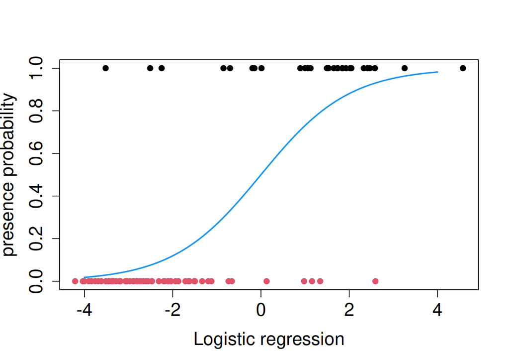

```r
xGrid <- seq(-4, 4, by=.001)
orderRegL <- order(regL$linPred)
plot(regL$linPred, Presence, xlab='Logistic regression', ylab='presence probability',
     pch=20, cex=1.5, cex.axis=1.5, cex.lab=1.5, col=2-Presence);
lines(xGrid, plogis(xGrid), col=4, lwd=2);
```

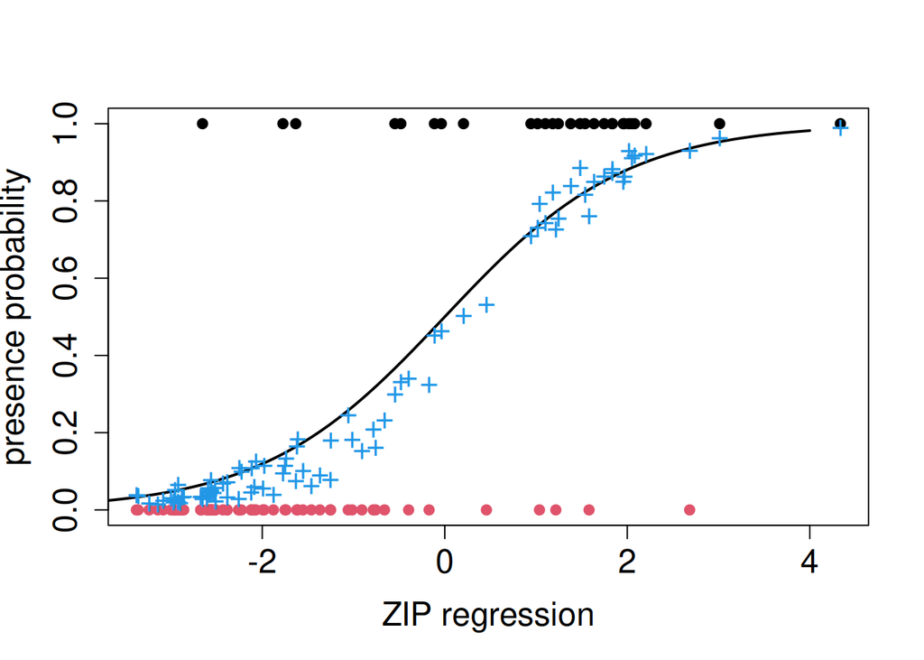

```r
# ZIP
orderZIP <- order(regZIP$linPredPresence)
orderZIP0 <- order(regZIP$linPredPresence[which(!Presence)])
plot(regZIP$linPredPresence, Presence, xlab='ZIP regression', ylab='presence probability',
     pch=20, cex=1.5, cex.axis=1.5, cex.lab=1.5, col=2-Presence);
lines(xGrid, plogis(xGrid), lwd=2);
points(regZIP$linPredPresence[orderZIP],regL$fitted.values[orderZIP], pch='+', col=4, cex=1.5)
```

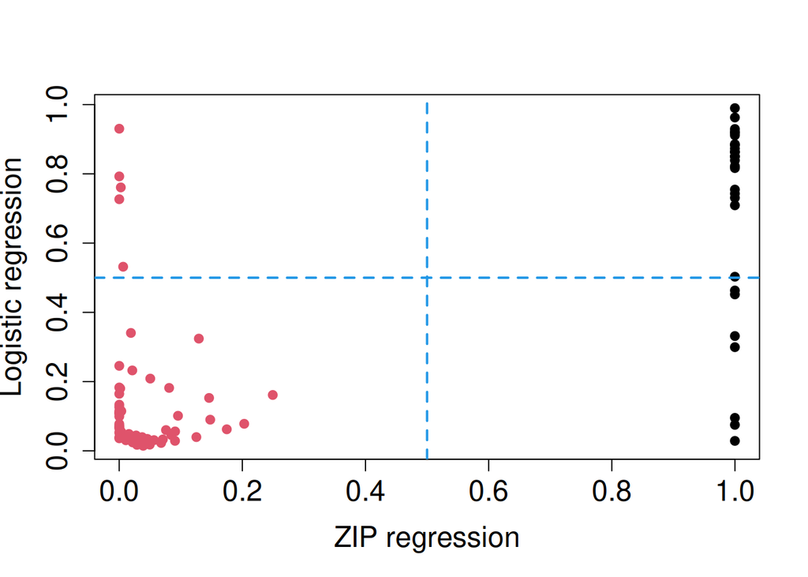

```r
# comparison
plot(regZIP$tau, regL$fitted.values,
     xlab='ZIP regression',  ylab='Logistic regression',
     pch=20, col=1+(Abundance==0), cex=1.5, cex.axis=1.5, cex.lab=1.5)
abline(v=.5, h=.5, col=4, lty=2, lwd=2)
```

## References

Chiquet, J., M. Mariadassou, and S. Robin. 2021. “The Poisson-Lognormal Model as a Versatile Framework for the Joint Analysis of Species Abundances.” *Frontiers in Ecology and Evolution* 9: 188. https://doi.org/10.3389/fevo.2021.588292.

Fossheim, M., E. M Nilssen, and M. Aschan. 2006. “Fish Assemblages in the Barents Sea.” *Marine Biology Research* 2 (4): 260–69.